# Activity 07 - Multiple Linear Regression Practice

STS 2300

Updated: 2025-03-22

We will use the following R packages during today’s activity.

```r
library(ggplot2)
library(dplyr)
library(moderndive)
```

For this activity, we’ll use a dataset called `mario_kart_auction` from the `modenrndive` R package. The data frame includes information from 143 eBay auctions for the Nintendo Wii game Mario Kart. Our goal is to predict the total price at the end of the auction (`total_pr`).

We will consider the following variables as possible variables to help us make our prediction:

- `duration` - auction length
- `start_pr` - starting price for the auction
- `ship_pr` - amount listed for shipping price
- `seller_rate` - seller’s eBay rating
- `wheels` - number of Wii wheels included with the game in the auction
1. Make a graph to explore the distribution of the response variable. What do you notice? (Note: This is just asking you to make a graph of a single variable, not to compare variables to one another)

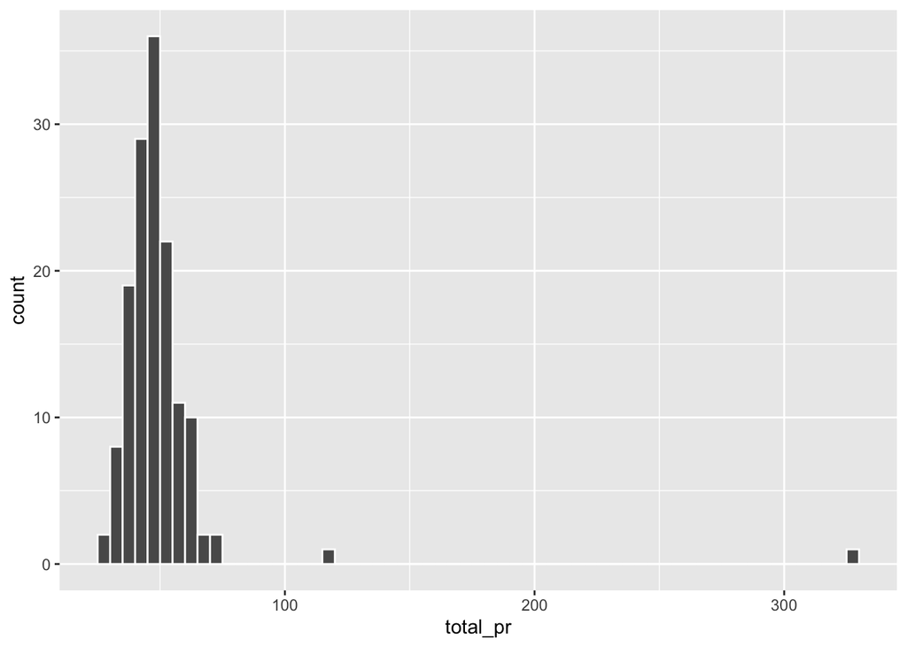

```r
mario_kart_auction |>
  ggplot(aes(x = total_pr)) +
  geom_histogram(color = "white",
                 binwidth = 5,
                 boundary = 0)
```

**Answer:** There were two auctions that had total prices MUCH higher than the rest.

2. Outliers can have a **BIG** impact on regression analyses. While we don’t know why those two auction values were so high, it seems pretty obvious that there was something different happening in them than in other auctions. Try creating a new data frame called `mario` that removes those two values. Then re-graph the response variable.

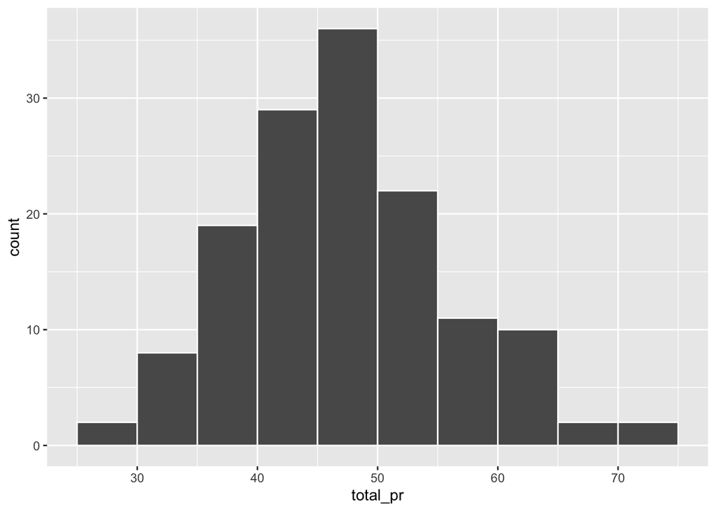

```r
mario <- mario_kart_auction |>
  filter(total_pr < 100)

mario |>
  ggplot(aes(x = total_pr)) +
  geom_histogram(color = "white",
                 binwidth = 5,
                 boundary = 0)
```

3. Let’s use R to create a multiple linear regression model with your new data frame that will predict `total_pr` using all of the possible explanatory variables listed at the top of this activity (`duration`, `start_pr`, `ship_pr`, `seller_rate`, and `wheels`). Use the `summary()` function to better explore the results. Are there any variables that we may want to remove? Why?

```r
mario.lm <- lm(total_pr ~ duration + start_pr + ship_pr + seller_rate + wheels,
               data = mario)

summary(mario.lm)
```

```
##
## Call:
## lm(formula = total_pr ~ duration + start_pr + ship_pr + seller_rate +
##     wheels, data = mario)
##
## Residuals:
##     Min      1Q  Median      3Q     Max
## -10.139  -2.989   0.391   2.019  17.019
##
## Coefficients:
##               Estimate Std. Error t value Pr(>|t|)
## (Intercept)  3.843e+01  1.170e+00  32.834  < 2e-16 ***
## duration    -5.329e-01  1.849e-01  -2.882 0.004603 **
## start_pr     1.081e-01  3.014e-02   3.586 0.000468 ***
## ship_pr      1.362e-01  1.623e-01   0.839 0.402785
## seller_rate  2.565e-05  8.753e-06   2.930 0.003975 **
## wheels       8.032e+00  5.520e-01  14.550  < 2e-16 ***
## ---
## Signif. codes:  0 '***' 0.001 '**' 0.01 '*' 0.05 '.' 0.1 ' ' 1
##
## Residual standard error: 4.836 on 135 degrees of freedom
## Multiple R-squared:  0.7285, Adjusted R-squared:  0.7185
## F-statistic: 72.46 on 5 and 135 DF,  p-value: < 2.2e-16
```

**Answer:** The `ship_pr` variable has a p-value of 0.403, which is the highest of the slope terms (and is above 0.05). This suggests this variable may not actually be useful in our regression when we have all the others included.

4. After using backward selection to arrive at a final model, what is your equation? Fill in the equation below for this model. Use this model to answer the remaining questions.

```r
mario.lm_final <- lm(total_pr ~ duration + start_pr + seller_rate + wheels,
               data = mario)

summary(mario.lm_final)
```

```
##
## Call:
## lm(formula = total_pr ~ duration + start_pr + seller_rate + wheels,
##     data = mario)
##
## Residuals:
##      Min       1Q   Median       3Q      Max
## -10.2589  -2.9377   0.4692   2.0070  16.6911
##
## Coefficients:
##               Estimate Std. Error t value Pr(>|t|)
## (Intercept)  3.862e+01  1.147e+00  33.684  < 2e-16 ***
## duration    -4.916e-01  1.781e-01  -2.761  0.00656 **
## start_pr     1.079e-01  3.010e-02   3.584  0.00047 ***
## seller_rate  2.603e-05  8.732e-06   2.981  0.00341 **
## wheels       8.079e+00  5.486e-01  14.727  < 2e-16 ***
## ---
## Signif. codes:  0 '***' 0.001 '**' 0.01 '*' 0.05 '.' 0.1 ' ' 1
##
## Residual standard error: 4.83 on 136 degrees of freedom
## Multiple R-squared:  0.7271, Adjusted R-squared:  0.7191
## F-statistic:  90.6 on 4 and 136 DF,  p-value: < 2.2e-16
```

$$\widehat{totalprice} = 38.62 − 0.4916 ∗
\text{duration} + 0.1079 ∗ \text{start_pr} + 0.000026 ∗
\text{seller_rate} + 8.079 ∗ \text{wheels}$$

5. Write a sentence interpreting the y-intercept of your model in context of this example. Does the interpretation make sense in this context? (Note: Remember we need to add a bit more for multiple linear regression interpretations.)

**Interpretation:** The predicted final auction price is $38.62 for an auction with a duration of 0 days, a start price of $0, a seller rating of 0, and 0 wheels included. This interpretation is an extrapolation and does not make sense because it’s impossible to have an auction with a duration of 0 days. It may make sense to have values of 0 for the other three explanatory variables though.

6. Write a sentence interpreting the slope for the `start_pr` variable in context of this example. Remember to consider what the units are for this example. (Note: Remember we need to add a bit more for multiple linear regression interpretations.)

**Interpretation:** The predicted final price increases by $0.11 (or 11 cents) for every 1 dollar increase in the starting price of the auction (assuming duration, seller rating, and wheels are held constant).

7. Write a sentence interpreting the slope for the `duration` variable in context of this example. Remember to consider what the units are for this example. (Note: Remember we need to add a bit more for multiple linear regression interpretations.)

**Interpretation:** The predicted final price for the auction decreases by $0.49 (or 49 cents) for every 1 day increase in the duration of the auction (assuming starting price, seller rating, and wheels are held constant).

8. Does it make sense to say that an eBay seller should set the duration as short as possible to make more money? Why or why not?

**Answer:** Not necessarily. There will be a lower limit to how short of an auction is effective. This is just the relationship we saw within the bounds of our data.

9. Calculate the predicted price for a 7 day auction with a starting price of $25, a shipping price of $8.70, a seller rating of 3085, and 1 wheel included. (Note: Your model may not include all of these variables in it. In that case, you can ignore the ones that are not part of your model.)

```r
mario.lm_final |>
  predict(newdata = data.frame(duration = 7,
                               start_pr = 25,
                               seller_rate = 3085,
                               wheels = 1))
```

```
##        1
## 46.03549
```

**Prediction =** $46.04

10. There was an auction in our data that matches the prediction above. It had a total price of $40.70. What is the residual for this value?

```r
40.7 - 46.04
```

```
## [1] -5.34
```

**Residual =** -$5.34

11. What is the $R^2$ for our model? Write a sentence interpreting it in context.

```r
summary(mario.lm_final)
```

```
##
## Call:
## lm(formula = total_pr ~ duration + start_pr + seller_rate + wheels,
##     data = mario)
##
## Residuals:
##      Min       1Q   Median       3Q      Max
## -10.2589  -2.9377   0.4692   2.0070  16.6911
##
## Coefficients:
##               Estimate Std. Error t value Pr(>|t|)
## (Intercept)  3.862e+01  1.147e+00  33.684  < 2e-16 ***
## duration    -4.916e-01  1.781e-01  -2.761  0.00656 **
## start_pr     1.079e-01  3.010e-02   3.584  0.00047 ***
## seller_rate  2.603e-05  8.732e-06   2.981  0.00341 **
## wheels       8.079e+00  5.486e-01  14.727  < 2e-16 ***
## ---
## Signif. codes:  0 '***' 0.001 '**' 0.01 '*' 0.05 '.' 0.1 ' ' 1
##
## Residual standard error: 4.83 on 136 degrees of freedom
## Multiple R-squared:  0.7271, Adjusted R-squared:  0.7191
## F-statistic:  90.6 on 4 and 136 DF,  p-value: < 2.2e-16
```

**$R^2$ =** 0.7271

**Interpretation:** Around 73% of the variability in final eBay auction price for Mario Kart on Nintendo Wii can be explained by the duration of the auction, the starting price, the seller rating, and the number of wheels included.